# (Ford GoBike Visualizations And Insights)

## Investigation Overview

**This presentation shows the most user type, who of these users will finish the trip faster, and why the finish it faster.**

## Dataset Overview

```python
# import all packages and set plots to be embedded inline
import numpy as np
import pandas as pd
import matplotlib.pyplot as plt
import seaborn as sb

%matplotlib inline

# suppress warnings from final output
import warnings
warnings.simplefilter("ignore")
```

```python
# load in the dataset into a pandas dataframe
df_clean = pd.read_csv('clean_file.csv')
df_clean.head()
```

|  | duration_sec | start_time | end_time | start_station_id | start_station_name | start_station_latitude | start_station_longitude | end_station_id | end_station_name | end_station_latitude | end_station_longitude | bike_id | user_type | duration_min |
| --- | --- | --- | --- | --- | --- | --- | --- | --- | --- | --- | --- | --- | --- | --- |
| 0 | 9226 | 2017-12-31 22:51:00.918 | 2018-01-01 01:24:47.166 | 30 | San Francisco Caltrain (Townsend St at 4th St) | 37.776598 | -122.395282 | 30 | San Francisco Caltrain (Townsend St at 4th St) | 37.776598 | -122.395282 | 1487 | Customer | 153 |
| 1 | 4507 | 2017-12-31 23:49:28.422 | 2018-01-01 01:04:35.619 | 259 | Addison St at Fourth St | 37.866249 | -122.299371 | 259 | Addison St at Fourth St | 37.866249 | -122.299371 | 3539 | Customer | 75 |
| 2 | 4334 | 2017-12-31 23:46:37.196 | 2018-01-01 00:58:51.211 | 284 | Yerba Buena Center for the Arts (Howard St at ... | 37.784872 | -122.400876 | 284 | Yerba Buena Center for the Arts (Howard St at ... | 37.784872 | -122.400876 | 1503 | Customer | 72 |
| 3 | 4150 | 2017-12-31 23:37:07.548 | 2018-01-01 00:46:18.308 | 20 | Mechanics Monument Plaza (Market St at Bush St) | 37.791300 | -122.399051 | 20 | Mechanics Monument Plaza (Market St at Bush St) | 37.791300 | -122.399051 | 3125 | Customer | 69 |
| 4 | 4238 | 2017-12-31 23:35:38.145 | 2018-01-01 00:46:17.053 | 20 | Mechanics Monument Plaza (Market St at Bush St) | 37.791300 | -122.399051 | 20 | Mechanics Monument Plaza (Market St at Bush St) | 37.791300 | -122.399051 | 2543 | Customer | 70 |

> Note that the above cells have been set as "Skip"-type slides. That means that when the notebook is rendered as http slides, those cells won't show up.

## What are the most user type

**The chart shows what are the most user type that we have in our dataset, and the most user type we have is the (Subscribers)**

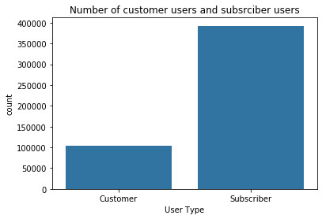

```python
df_color = sb.color_palette()[0]
sb.countplot(data = df_clean, x = 'user_type', color = df_color);
plt.xlabel('User Type');
plt.title('Number of customer users and subsrciber users');
```

## What type of users is faster on finishing the trip

**This plot shows who are the user type that finishes the trip faster, and it is looks like the (subsrcibers) is faster than the (Customers)**

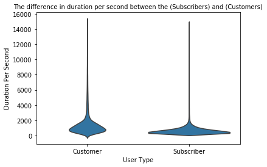

```python
sb.violinplot(data = df_clean, x = 'user_type', y = 'duration_sec',color = df_color, inner = None);
plt.title('The difference in duration per second between the (Subscribers) and (Customers)', size = 10);
plt.xlabel('User Type')
plt.ylabel('Duration Per Second')
```

## Why the subscribers is faster than the customers

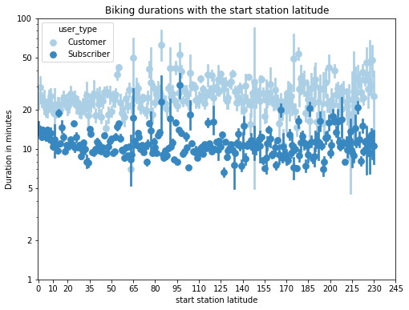

```python
fig = plt.figure(figsize = [8,6]);
ax = sb.pointplot(data = df_clean, x = 'start_station_latitude', y = 'duration_min', hue = 'user_type',
           palette = 'Blues', linestyles = '');
plt.title('Biking durations with the start station latitude')
plt.xlabel('start station latitude')
plt.ylabel('Duration in minutes')
plt.yscale('log')
plt.yticks([1, 2, 5, 10, 20, 50, 100], [1, 2, 5, 10, 20, 50, 100]);
plt.xticks([0,10,20,35,50,65,80,95,110,125,140,155,170,185,200,215,230,245],[0,10,20,35,50,65,80,95,110,125,140,155,170,185,200,215,230,245]);
ax.set_yticklabels([],minor = True);
```

## Why the subscribers is faster than the customers

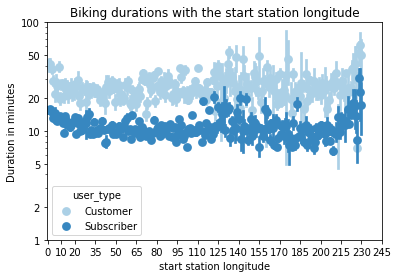

```python
ax = sb.pointplot(data = df_clean, x = 'start_station_longitude', y = 'duration_min', hue = 'user_type',
           palette = 'Blues', linestyles = '');
plt.title('Biking durations with the start station longitude')
plt.xlabel('start station longitude')
plt.ylabel('Duration in minutes')
plt.yscale('log')
plt.yticks([1, 2, 5, 10, 20, 50, 100], [1, 2, 5, 10, 20, 50, 100]);
plt.xticks([0,10,20,35,50,65,80,95,110,125,140,155,170,185,200,215,230,245],[0,10,20,35,50,65,80,95,110,125,140,155,170,185,200,215,230,245]);
ax.set_yticklabels([],minor = True);
```

# Thank You :)

> Once you're ready to finish your presentation, check your output by using nbconvert to export the notebook and set up a server for the slides. From the terminal or command line, use the following expression:

> > `jupyter nbconvert <file_name>.ipynb --to slides --post serve --template output_toggle`

> This should open a tab in your web browser where you can scroll through your presentation. Sub-slides can be accessed by pressing 'down' when viewing its parent slide. Make sure you remove all of the quote-formatted guide notes like this one before you finish your presentation!